# A3 The GESIS Panel data

Jan-Philipp Kolb

06 August 2018

## Das GESIS Panel

- Wahrscheinlichkeitsbasiertes Access Panel für Individuen: - Allgemeine Bevölkerung in Deutschland, Deutschsprachhige Bevölkerung, 18-70 Jahre
- Panelisten wurden aus den Melderegistern rekrutiert - (270 Sampling Points) 7599 face-to-face Interviews (CAPI)
- Ungefähr 5000 Panelisten (Basis Stichprobe / erste Kohorte 2014)

## Das GESIS Panel Campus File

[figure not shown]

## Download data

- Übersichtsseite: [**GESIS Panel Campus File**](https://www.gesis.org/gesis-panel/data/)
- Registrierung notwendig

### Links für den Download:

- [**Download `.csv`**](https://dbk.gesis.org/dbksearch/download.asp?db=D&id=62367)
- [**Download `.sav`**](https://dbk.gesis.org/dbksearch/download.asp?db=D&id=62369)
- [**Download `**14.dta`**](https://dbk.gesis.org/dbksearch/download.asp?db=D&id=62371)

## Einen ersten Eindruck von den Daten bekommen

- bbzc022a - Häufigkeit politische Nachrichten
- bfam051a - MPMB Capacity: Termine fallen rechtzeitig ein
- bfzi023a - Umfragen GESIS GM: Interessant
- baai124a - Schwierigkeit Fragebogen zu verstehen

| bbzc022a | bfam051a | bfzi023a | baai124a |
| --- | --- | --- | --- |
| Täglich weniger als eine Stunde | Eher selten | 7 Stimme voll und ganz zu | Etwas schwierig |
| Täglich weniger als eine Stunde | Eher oft | 6 | Überhaupt nicht schwierig |
| Täglich weniger als eine Stunde | Eher selten | 2 | Etwas schwierig |
| Einmal im Monat oder seltener | Eher oft | 7 Stimme voll und ganz zu | Überhaupt nicht schwierig |
| Täglich weniger als eine Stunde | Eher oft | 3 | Überhaupt nicht schwierig |
| Einmal in der Woche | Not reached | 4 | Etwas schwierig |

## Die Variablennamen im GESIS Panel

### Beispiel für die Zusammensetzung der Variablennamen

```
## [1] "bezf044a" "bdze018a" "bdao036b" "bfzi029a" "bezg091a"
```

- Die ersten beiden Buchstaben enthalten die Welle:

| year | waves | numbers |
| --- | --- | --- |
| 2013 | aa,ab,ac | 1-3 |
| 2014 | ba,bb,bc,bd,be,bf | 4-9 |
| 2015 | ca,cb,cc,cd,ce,cf | 10-15 |
| 2016 | da,db,dc,dd,de,df | 16-21 |
| 2017 | ea,eb,ec,ed,ee,ef | 22-27 |
| 2018 | fa,fb,fc,fd,fe,ff | 28-33 |

- Bis zum jetzigen Zeitpunkt sind 32 gelaufen

## Die Variablennamen im GESIS Panel II

- Die Stellen drei und vier geben Information über die Studie:

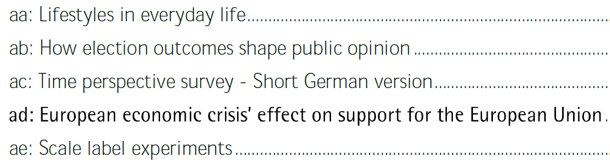

- Die Stellen fünf, sechs und sieben indizieren die Variablennummer
- Die letzte Stelle enthält die Information, ob es sich um eine originale Variable (a) oder eine synthetische Variable handelt (b,c,d,e,…)

## Variablennamen im GESIS Panel

### Beispiel Geburtsdatum - `cfzh072c`

```
## [1] "cfzh072c"
```

```
## [1] "Welle:  cf"
```

```
## [1] "Studie:  zh"
```

```
## [1] "Variablen Nr.:  072"
```

```
## [1] "Synthetische Variable?:  c"
```

## Die Variablen im Campus File

https://rpubs.com/Japhilko82/VarsGesisPanel

[figure not shown]

## Wellen im Campus File

- Welche Wellen sind im Campus file?
- Anzahl Variablen pro Welle im Campus File:

```
## waves
##  a1  ba  bb  bc  bd  be  bf  z0
## 171 171 154 155 224 185 128   4
```

## Studien im Campus File

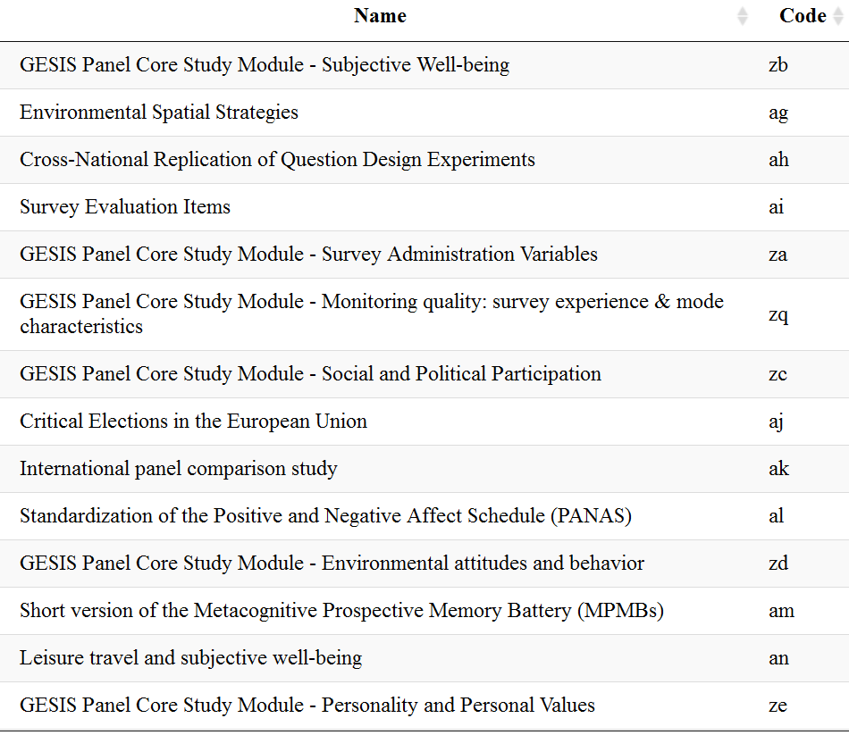

## Die Missing Codes im GESIS Panel

| Value | Value.label | Remark |
| --- | --- | --- |
| -11 | Not invited | only in recruitment waves - when profile survey not finished |
| -22 | Not in panel | not willing to join the panel after recruitment or signing off |
| -33 | Unit nonresponse | invited but not participating in corresponding wave |
| -44 | Missing by m.o.p. | mode of participation (m.o.p.): online or offline |
| -55 | Missing by technical error | e.g. questionnaire programming error |
| -66 | Missing by design | experimental variation |
| -77 | Not reached | only in online mode: panelist has not seen the item |
| -88 | Missing by filter | filtered item |
| -99 | Item nonresponse | due to nonresponse by the respondent |
| -111 | Ambiguous answer | ambiguous answers in questionnaire |

## Zufriedenheit Leben in Wohnort (a11c019a)

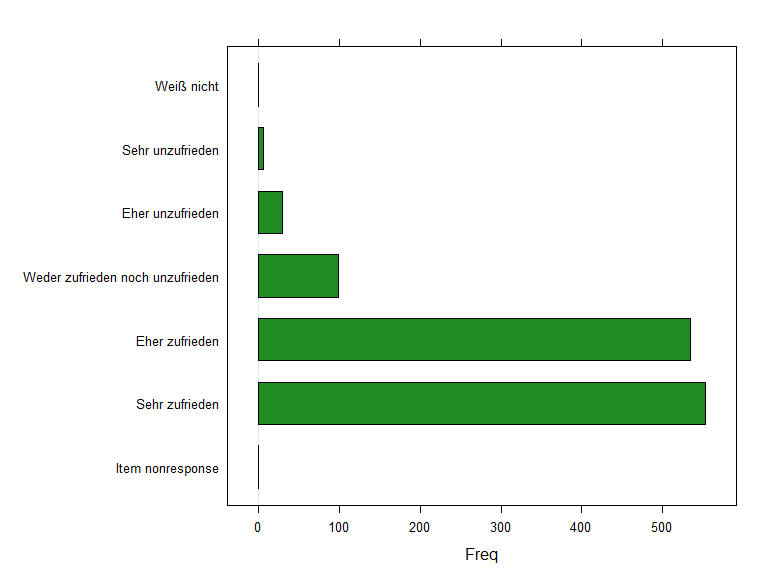

## Das Codebuch

- Das Codebuch kann man [**hier**](https://www.gesis.org/gesis-panel/documentation/) bekommen.

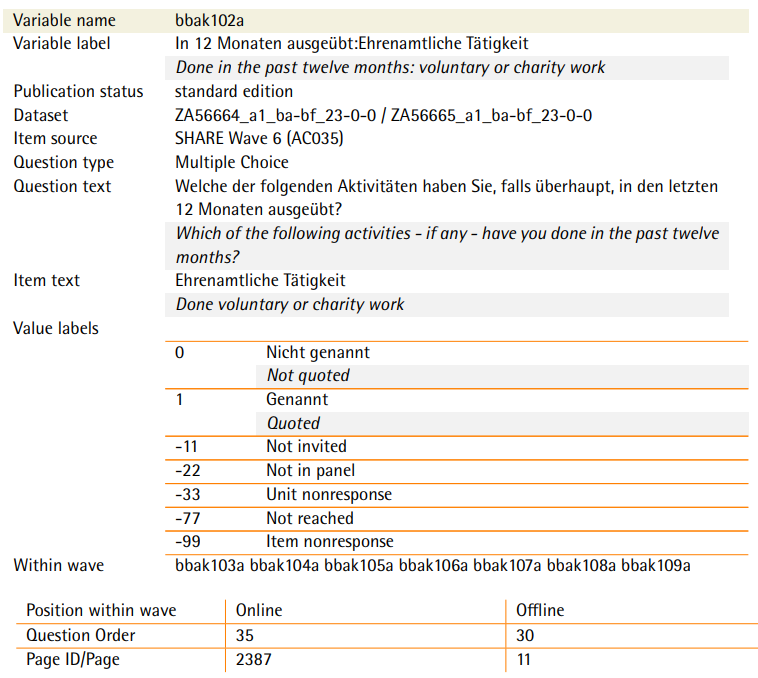

## Eine Übersicht über das GESIS Panel (Campus File)

- [**Dashboard zum Überblick**](http://rpubs.com/Japhilko82/overview_gp)

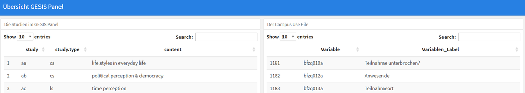

## A3A Aufgabe - Download der GESIS Panel Daten

- Suche bei einer Suchmaschine nach GESIS Panel Campus file oder
- gehe auf die Seiten des GESIS Datenbestandskatalogs und
- lade die `**14.dta` Datei des GESIS Panel Campus file herunter.